# Data Management

Walter Quattrociocchi

**Segmentation: Clustering and Classification**

### Segmentation as Clustering & Classification

Segmentation is a process of finding groups of customers who are **similar to one another**, are **different from other groups**, and exhibit differences that are **important for the business**.

There is **no magic method** to solve all three of those requirements simultaneously.

Segmentation requires trying **multiple methods** and evaluating the results to determine whether they are useful for the business question.

It often occurs that the statistically “best” segmentation is difficult to understand in the business context. A model that is statistically “not as strong” – but is clear and actionable – may be a preferable result.

In this lesson, we give an overview of methods to demonstrate some common approaches.

### Clustering vs Classification

Clustering is the process of *finding* groups inside data. Key problems include:

- Determining which variables to use
- Finding the right number of clusters
- Ensuring the groups differ in interesting ways

Classification is the process of *assigning* observations (e.g., customers) to known categories (segments, clusters). Some important concerns are:

- Predicting better than chance
- Optimizing for positive vs. negative prediction
- Generalizing to new data sets

## Clustering

### Example data

```r
seg.raw <- read.csv("http://goo.gl/qw303p")
head(seg.raw)
```

```
       age gender   income kids ownHome subscribe    Segment
1 47.31613   Male 49482.81    2   ownNo     subNo Suburb mix
2 31.38684   Male 35546.29    1  ownYes     subNo Suburb mix
3 43.20034   Male 44169.19    0  ownYes     subNo Suburb mix
4 37.31700 Female 81041.99    1   ownNo     subNo Suburb mix
5 40.95439 Female 79353.01    3  ownYes     subNo Suburb mix
6 43.03387   Male 58143.36    4  ownYes     subNo Suburb mix
```

### Example data

```r
seg.df  <- seg.raw[ , -7]     # remove the known segment assignments
head(seg.df)
```

```
       age gender   income kids ownHome subscribe
1 47.31613   Male 49482.81    2   ownNo     subNo
2 31.38684   Male 35546.29    1  ownYes     subNo
3 43.20034   Male 44169.19    0  ownYes     subNo
4 37.31700 Female 81041.99    1   ownNo     subNo
5 40.95439 Female 79353.01    3  ownYes     subNo
6 43.03387   Male 58143.36    4  ownYes     subNo
```

### Group differences

We create a simple function to look at mean values by group. (This is a placeholder for a more complex evaluation of an interpretable business outcome.)

```r
seg.summ <- function(data, groups) {
  aggregate(data, list(groups), function(x) mean(as.numeric(x)))
}

seg.summ(seg.df, seg.raw$Segment)
```

```
     Group.1      age gender   income     kids  ownHome subscribe
1  Moving up 36.33114   1.30 53090.97 1.914286 1.328571     1.200
2 Suburb mix 39.92815   1.52 55033.82 1.920000 1.480000     1.060
3  Travelers 57.87088   1.50 62213.94 0.000000 1.750000     1.125
4  Urban hip 23.88459   1.60 21681.93 1.100000 1.200000     1.200
```

### Distance

Clustering methods work by looking at some measure of the *distance* between observations. They try to find groups whose members are close to one another (and far from others).

A common metric is *Euclidian distance*, the root square of differences:

```r
c(1,2,3) - c(2,3,2)
[1] -1 -1  1
sum((c(1,2,3) - c(2,3,2))^2)
[1] 3
sqrt(sum((c(1,2,3) - c(2,3,2))^2))
[1] 1.732051
```

Note that distance is between *observations*, and the result is a matrix of distances between all pairs (in this case, just one pair).

### dist()

`dist()` computes Euclidian distance:

```r
sqrt(sum((c(1,2,3) - c(2,3,2))^2))
```

```
[1] 1.732051
```

```r
dist(rbind(c(1,2,3), c(2,3,2)))
```

```
         1
2 1.732051
```

In case of mixed data types (e.g., continuous, binary, ordinal), `dist()` may not be appropriate because of the huge implied scale differences.

### daisy()

`daisy()` is an alternative that automatically rescales.

```r
library(cluster)
seg.dist <- daisy(seg.df)       # daisy works with mixed data types
as.matrix(seg.dist)[1:4, 1:4]   # distances of first 4 observations
```

```
          1         2         3         4
1 0.0000000 0.2532815 0.2329028 0.2617250
2 0.2532815 0.0000000 0.0679978 0.4129493
3 0.2329028 0.0679978 0.0000000 0.4246012
4 0.2617250 0.4129493 0.4246012 0.0000000
```

### Hierarchical Clustering

- Hierarchical clustering combines closest neighbors (defined in various ways) into progressively larger groups.
- In R, we first compute distances (previous slide) and then cluster those:

```r
seg.hc <- hclust(seg.dist, method="complete")
```

### Hierarchical Clustering

Plot the result to see a tree of the solution:

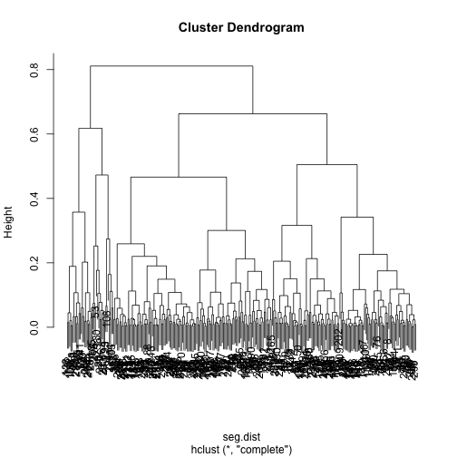

```r
plot(seg.hc)
```

### Examining Similarities

We can cut the tree at a particular height and plot above or below. In this case, we cut at a height of `0.5`. Then we plot the first (`$lower[[1]]`) of the resulting trees below that:

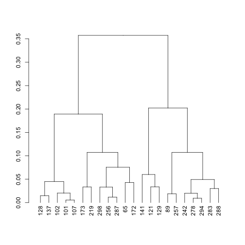

```r
plot(cut(as.dendrogram(seg.hc), h=0.5)$lower[[1]])
```

### Comparing observations in branches

From the previous tree, we select observations from close and far branches:

```r
seg.df[c(101, 107), ]  # similar
```

```
         age gender   income kids ownHome subscribe
101 24.73796   Male 18457.85    1   ownNo    subYes
107 23.19013   Male 17510.28    1   ownNo    subYes
```

```r
seg.df[c(278, 294), ]  # similar
```

```
         age gender   income kids ownHome subscribe
278 36.23860 Female 46540.88    1   ownNo    subYes
294 35.79961 Female 52352.69    1   ownNo    subYes
```

```r
seg.df[c(173, 141), ]  # less similar
```

```
         age gender   income kids ownHome subscribe
173 64.70641   Male 45517.15    0   ownNo    subYes
141 25.17703 Female 20125.80    2   ownNo    subYes
```

### Comparing the dendrogram to the distance matrix

- The cophenetic correlation coefficient is a measure of how well the clustering model (expressed in the dendrogram) reflects the distance matrix
- It can be argued that a dendrogram is an appropriate summary of some data if the correlation between the original distances and the cophenetic distances is high

```r
cor(cophenetic(seg.hc), seg.dist)
```

```
[1] 0.7682436
```

### Getting K groups from the tree

To get K groups, read from the top of the dendrogram *until there are K branches*.

`rect.hclust()` shows where the tree would be cut for K groups:

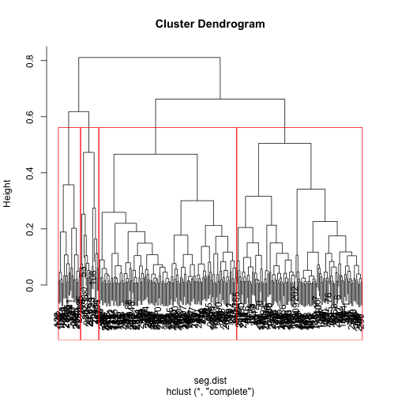

```r
plot(seg.hc)
rect.hclust(seg.hc, k=4, border="red")
```

### Getting segment membership from hclust

Get a vector of class (cluster) assignment:

```r
seg.hc.segment <- cutree(seg.hc, k=4)     # membership vector for 4 groups
table(seg.hc.segment)
```

```
seg.hc.segment
  1   2   3   4
124 136  18  22
```

### Getting segment membership from hclust

Compare them with our quick function:

```r
seg.summ(seg.df, seg.hc.segment)
```

```
  Group.1      age   gender   income     kids  ownHome subscribe
1       1 40.78456 2.000000 49454.08 1.314516 1.467742         1
2       2 42.03492 1.000000 53759.62 1.235294 1.477941         1
3       3 44.31194 1.388889 52628.42 1.388889 2.000000         2
4       4 35.82935 1.545455 40456.14 1.136364 1.000000         2
```

### Is the result interesting?

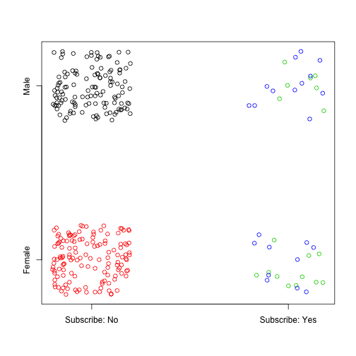

```r
plot(jitter(as.numeric(seg.df$gender)) ~
     jitter(as.numeric(seg.df$subscribe)),
       col=seg.hc.segment, yaxt="n", xaxt="n", ylab="", xlab="")
axis(1, at=c(1, 2), labels=c("Subscribe: No", "Subscribe: Yes"))
axis(2, at=c(1, 2), labels=levels(seg.df$gender))
```

Not really … subscribers are men and women. Time to iterate!

### K-means clustering

K-means attempts to find K groups, such that the sum of squared distances for points within clusters are minimized with respect to the cluster center.

To compute this, K-means requires *numeric* input and a specified number of clusters. We first convert our factor variables to numeric (arguably OK because they're binary):

```r
seg.df.num <- seg.df
seg.df.num$gender    <- ifelse(seg.df$gender=="Male", 0, 1)
seg.df.num$ownHome   <- ifelse(seg.df$ownHome=="ownNo", 0, 1)
seg.df.num$subscribe <- ifelse(seg.df$subscribe=="subNo", 0, 1)
head(seg.df.num)
```

```
       age gender   income kids ownHome subscribe
1 47.31613      0 49482.81    2       0         0
2 31.38684      0 35546.29    1       1         0
3 43.20034      0 44169.19    0       1         0
4 37.31700      1 81041.99    1       0         0
5 40.95439      1 79353.01    3       1         0
6 43.03387      0 58143.36    4       1         0
```

### Find the K-means groups

We try K=4 groups:

```r
set.seed(96743)        # because starting assignments are random
seg.k <- kmeans(seg.df.num, centers=4)
```

### Find the K-means groups

And examine the quick comparison:

```r
seg.summ(seg.df, seg.k$cluster)
```

```
  Group.1      age   gender   income      kids  ownHome subscribe
1       1 56.37245 1.428571 92287.07 0.4285714 1.857143  1.142857
2       2 29.58704 1.571429 21631.79 1.0634921 1.301587  1.158730
3       3 44.42051 1.452632 64703.76 1.2947368 1.421053  1.073684
4       4 42.08381 1.454545 48208.86 1.5041322 1.528926  1.165289
```

It appears potentially more interesting than the `hclust` “men and women” solution we saw previously.

### Comparing groups on 1 variable

In the model object, `...$cluster` holds the class assignments. We can use that as the IV for plotting:

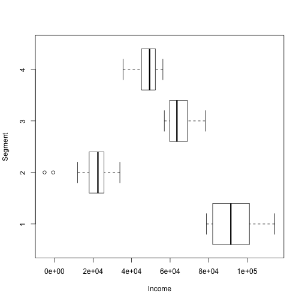

```r
boxplot(seg.df.num$income ~ seg.k$cluster,
        xlab="Income", ylab="Segment", horizontal=TRUE)
```

### Visualizing the overall clusters

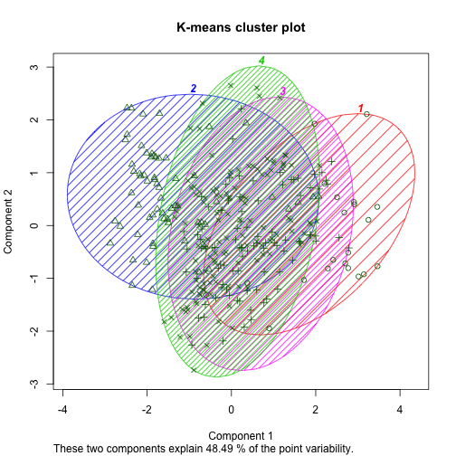

```r
library(cluster)
clusplot(seg.df, seg.k$cluster, color=TRUE, shade=TRUE,
         labels=4, lines=0, main="K-means cluster plot")
```

We see that group 1 is modestly well differentiated, and has the highest average income (that may make it a good target for a potential campaign). The key point is that the analysis provides interesting options to consider.

## Classification

Next we'll examine classification methods. Whereas clustering may help in determining when a solution is useful, classification tends to emphasize the “science” of predicting and generalizing.

### General concepts

Classification concerns assigning observations to a predefined set of groups. For example, we might wish to assign potential customers to higher- or lower-value prospects … or more generally, assign members of the overall population to a set of customer segments.

Classification can also assign customers to categories reflecting observed behavior, such as “purchasers.” It is one form of predictive modeling.

General steps in classification are:

1. **Collect data** with predictors & outcome
2. Divide the observations into **training and test cases**
3. Use training cases to **fit a model** predicting the outcomes
4. Confirm that the model **works well for test cases**
5. Apply the model to new data to **obtain predictions**

### Naive Bayes classification

The naive Bayes method is simple yet powerful. It uses Bayes's Rule to find the odds of class membership based on the conditional probabilities of predictor variables (assumed to be independent, thus “naive”).

More specifically, it computes conditional probabilities in the *training* data. The resulting model can then predict group membership probabilities for new observations (given the same predictors).

First we divide data into training and test cases:

```r
set.seed(04625)          # make it repeatable
train.prop   <- 0.65     # train on 65% of data. Hold 35% for testing
train.cases  <- sample(nrow(seg.raw), nrow(seg.raw)*train.prop)
seg.df.train <- seg.raw[ train.cases, ]
seg.df.test  <- seg.raw[-train.cases, ]
```

### Naive Bayes model

We fit the model to training data:

```r
library(e1071)
seg.nb <- naiveBayes(Segment ~ ., data=seg.df.train)
```

… and predict membership expected in the test (holdout) data:

```r
seg.nb.class <- predict(seg.nb, seg.df.test)

prop.table(table(seg.nb.class))
```

```
seg.nb.class
 Moving up Suburb mix  Travelers  Urban hip
 0.2285714  0.3047619  0.3428571  0.1238095
```

### Plot the predicted classes

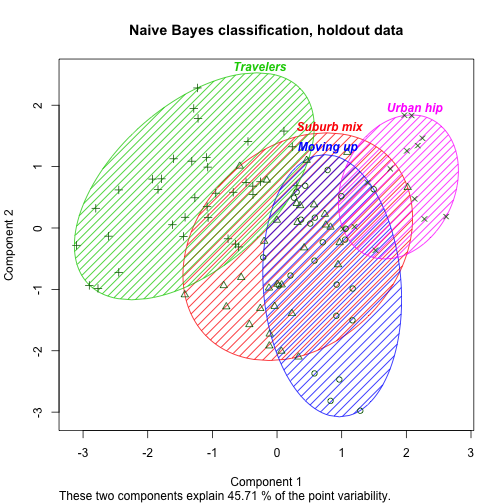

```r
clusplot(seg.df.test[, -7], seg.nb.class, color=TRUE, shade=TRUE,
         labels=4, lines=0,
         main="Naive Bayes classification, holdout data")
```

### How well did we do in the test data?

We could compare the proportion of correct assignments:

```r
mean(seg.df.test$Segment==seg.nb.class)   # raw correct proportion
```

```
[1] 0.8
```

… but better is to assess vs. chance assignment. (If one group is very large, we can't say a model is good just because it mostly predicts that group.)

```r
library(mclust)
adjustedRandIndex(seg.nb.class, seg.df.test$Segment)
```

```
[1] 0.5626787
```

Even better would be a weighted payoff matrix, taking into account the value of correct positive and negative predictions.

### Random Forests

Another way to do classification is with a decision tree: find an optimal decision path to predict the outcomes. A random forest model generalizes this to use many trees – fitting different predictors and observations – that “vote” on classification.

### Random Forests

Like naive Bayes classifiers, Random forests are simple and easy to use, yet often perform well.

We fit a random forest with 3000 individual trees, on the *training* data:

```r
library(randomForest)
set.seed(98040)
seg.rf <- randomForest(Segment ~ ., data=seg.df.train, ntree=3000)
```

It is sometimes suggested to have 5-10 trees per observation for small data sets

### Random forest model

A simple inspection of the model shows key results:

```r
seg.rf
```

```
Call:
 randomForest(formula = Segment ~ ., data = seg.df.train, ntree = 3000)
               Type of random forest: classification
                     Number of trees: 3000
No. of variables tried at each split: 2

        OOB estimate of  error rate: 24.1%
Confusion matrix:
           Moving up Suburb mix Travelers Urban hip class.error
Moving up         29         19         0         1  0.40816327
Suburb mix        20         35         3         1  0.40677966
Travelers          0          3        48         0  0.05882353
Urban hip          0          0         0        36  0.00000000
```

It includes initial performance tests on holout data (from the *training* data), and was correct 76% of the time. It was best for Urban hip, with more error for Moving up & Suburb mix.

Concern about error rates depends on interest in the segments.

#### random forest

### Make predictions for the test data

Apply the random forest to the test data:

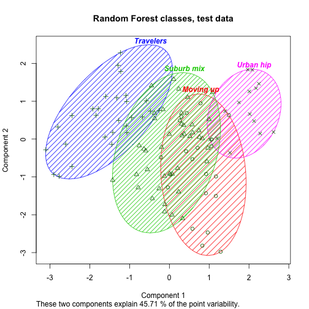

```r
seg.rf.class <- predict(seg.rf, seg.df.test)

library(cluster)
clusplot(seg.df.test[, -7], seg.rf.class, color=TRUE, shade=TRUE,
         labels=4, lines=0, main="Random Forest classes, test data")
```

### Variable importance

Random forests can cleverly assess importance of predictors: randomize (permute) a predictor's data and see whether predictions get worse.

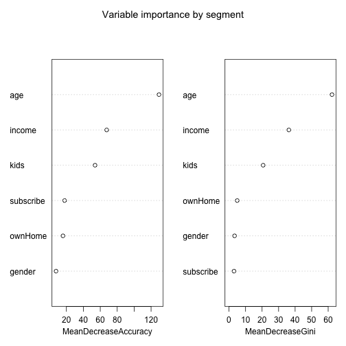

```r
set.seed(98040)
seg.rf <- randomForest(Segment ~ ., data=seg.df.train,
                       ntree=3000, importance=TRUE)
# importance(seg.rf)   # omitted: the actual metrics
varImpPlot(seg.rf, main="Variable importance by segment")
```

### A heatmap for variable importance

Importance might be used (e.g.) to determine which variables are “must collect” for a project:

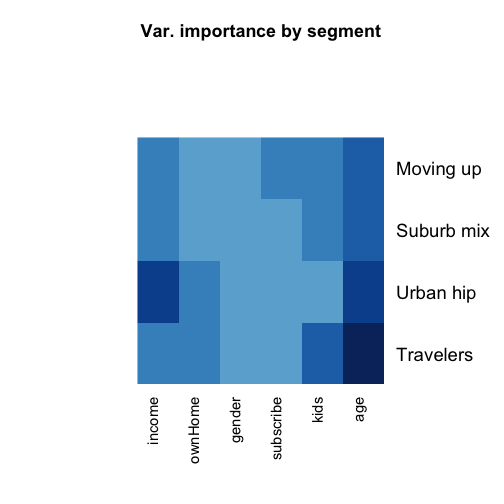

```r
library(gplots)
library(RColorBrewer)
heatmap.2(t(importance(seg.rf)[ , 1:4]), key=FALSE,
          col=brewer.pal(20, "Blues"),
          dend="none", trace="none", margins=c(10, 10),
          main="Var. importance by segment" )
```

### Conclusion: A Few Key Points

Segmentation is not a method, but a *process* that must focus clearly on the business need and question. Sometimes a “better” model is less useful.

*Clustering* can help identify potentially interesting groups in the data. Appropriateness of a solutions depends on both statistical criteria (fit) and business utility (clarity, ability to target, etc.)

If specific groups are known (e.g., segments or behaviors), *classification* methods find rules to predict membership in those groups. Depending on cost & margin, one might target more or fewer customers based on likelihood.

Important considerations for classification include performance on holdout data, generalization to new data sets, and avoiding class imbalance problems.

### Suggested Readings

James, Witten, Hastie, & Tibshirani (2013). *An Introduction to Statistical Learning, with Applications in R*. New York: Springer.

- An excellent overview of a wide variety of statistical approaches to learning and classification.

Kuhn & Johnson (2013). *Applied Predictive Modeling*. New York: Springer.

- A detailed examination of how to build regression and classification models that generalize. It is focused on practical application and overcoming many typical problems of such projects. There is a superb related package (“caret”).

### Notes

This presentation is based on Chapter 11 of Chapman and Feit, *R for Marketing Research and Analytics* © 2015 Springer.

All code in the presentation is licensed under the Apache License, Version 2.0 (the “License”); you may not use this file except in compliance with the License. You may obtain a copy of the License at [http://www.apache.org/licenses/LICENSE-2.0\](http://www.apache.org/licenses/LICENSE-2.0%5C) Unless required by applicable law or agreed to in writing, software distributed under the License is distributed on an “AS IS” BASIS, WITHOUT WARRANTIES OR CONDITIONS OF ANY KIND, either express or implied. See the License for the specific language governing permissions and limitations under the License.